# Statcast Metrics: Analyzing and Predicting San Diego Padres Performance

Celestine Hoang, Jeff Ung, Weihao Lin, Rohun Kulshrestha, Aerin Chiu

## Introduction

As the age of information moves along, people are increasingly seeking out the statistics of anything that interests them. For a complex sport like baseball that involves many strategies and variables, fans and analysts are eager to uncover the specific factors that drive the performances of players and the outcomes of every game. Major League Baseball (MLB) provides a useful tool that displays Statcast metrics of the top players such as Launch Angle Sweet-Spot Percentage, Exit Velocity, Batted Ball Event, etc. For example, the leader of the aforementioned stats overall is Aaron Judge, who happens to be the American League MVP in 2024 (MLB, 2024). This EDA will aim to discover the most important of these metrics and develop a model that accurately predicts the game outcomes of the San Diego Padres as well as identify the potential best players. We will be testing different models in order to draw this conclusion and further explore the strengths and limitations of our methodology in the discussion. Understanding and interpreting these advanced metrics is crucial for maintaining a competitive edge as the competition intensifies.

## Question

How do Statcast metrics such as average hit speed, barrels, and expected home runs (XHR) influence the home run performance of San Diego Padres players? Can a predictive model based on these metrics accurately identify top-performing players and explain discrepancies between expected and actual home runs?

## Objectives

The insights from this study can be applied directly by MLB teams, sports analysts, and player development coaches. Key applications include: 1. Player Development: Training programs can be tailored to improve crucial performance metrics such as barrels and exit velocity helping players maximize their home run potential. 2. In-Game Strategy: Managers can adjust batting lineups and game strategies based on predicted player performance under various conditions. 3. Team Building: Front-office executives can use predictive models to identify undervalued players with high potential based on metrics like expected home runs (xHR) and weighted on-base average (xwOBA) optimizing roster construction while managing salary caps. 4. Performance Benchmarking: Analysts can compare individual player metrics to league averages identifying strengths and areas for improvement and ensuring players are continuously assessed and developed.

### Load packages

```r
library(tidyverse)
library(tidyverse)
library(ggplot2)
library(caret)
library(randomForest)
library(dplyr)
library(rsample)
library(recipes)
library(yardstick)
```

## The Data

The dataset for this analysis was compiled from Statcast leaderboards and MLB’s Baseball Savant, both of which are authoritative sources for advanced baseball statistics. These datasets offer a comprehensive view of player performance by providing metrics such as Expected Weighted On-Base Average (xwOBA), barrels (a measure of quality contact), exit velocity, and expected slugging percentage. Additionally, data on home runs, including expected home runs and their differences, enhances the ability to evaluate offensive efficiency and overall player impact.

This dataset was specifically curated to align with the research question, focusing on key performance metrics that influence game outcomes. By including data on San Diego Padres players who remained with the team throughout the season, the dataset allows for a precise examination of the factors driving team performance. Its combination of raw statistics and derived metrics creates a robust foundation for understanding how individual contributions affect overall results.

### Data Import

```r
all_homeruns <- read.csv("data/homeruns.csv")
sd_homeruns <- read.csv("data/homeruns_SD.csv")
all_expected_stats <- read.csv("data/expected_stats.csv")
sd_expected_stats <- read.csv("data/expected_stats_SD.csv")
all_exit_velocity <- read.csv("data/exit_velocity.csv")
sd_exit_velocity <- read.csv("data/exit_velocity_SD.csv")
```

### Data Wrangling

The data wrangling process ensured that the analysis was applied only to cleaned, relevant features while adhering to preprocessing requirements suitable for clustering models like KMeans, EM models, or other unsupervised learning methods.

#### Clean Column Names

To ensure consistency and facilitating merging later on, we rename the columns in all datasets to meaningful names. For instance, `player` is used for player names.

```r
colnames(all_homeruns) <- c("player", "team_abbrev", "year", "type", "avg_hr_trot",
                        "doubters", "mostly_gone", "no_doubters", "no_doubter_per",
                        "hr_total", "xhr", "xhr_diff")

colnames(sd_homeruns) <- c("player", "team_abbrev", "year", "type", "avg_hr_trot",
                        "doubters", "mostly_gone", "no_doubters", "no_doubter_per",
                        "hr_total", "xhr", "xhr_diff")


colnames(all_expected_stats) <- c("player", "player_id", "year", "pa", "bip",
                               "ba", "est_ba", "est_ba_minus_ba_diff", "slg",
                               "est_slg", "est_slg_minus_slg_diff", "woba",
                               "est_woba", "est_woba_minus_woba_diff")

colnames(sd_expected_stats) <- c("player", "player_id", "year", "pa", "bip",
                               "ba", "est_ba", "est_ba_minus_ba_diff", "slg",
                               "est_slg", "est_slg_minus_slg_diff", "woba",
                               "est_woba", "est_woba_minus_woba_diff")

colnames(all_exit_velocity) <- c("player", "player_id", "attempts", "avg_hit_angle",
                             "angle_sweet_spot_percent", "max_hit_speed", "avg_hit_speed",
                             "ev50", "fbld", "gb", "max_distance", "avg_distance",
                             "avg_hr_distance", "ev95plus", "ev95percent", "barrels",
                             "brl_percent", "brl_pa")

colnames(sd_exit_velocity) <- c("player", "player_id", "attempts", "avg_hit_angle",
                             "angle_sweet_spot_percent", "max_hit_speed", "avg_hit_speed",
                             "ev50", "fbld", "gb", "max_distance", "avg_distance",
                             "avg_hr_distance", "ev95plus", "ev95percent", "barrels",
                             "brl_percent", "brl_pa")
```

#### Handle Missing Values

We need to look for missing values in the columns since they can lead to inaccurate or biased analysis if not handled properly. If any missing values are found, we would input the median or mean of that column for that missing value. For instance, missing values in the `avg_hr_trot` and `no_doubter_per` columns are replaced with the median.

```r
colSums(is.na(all_homeruns))
```

```
##         player    team_abbrev           year           type    avg_hr_trot
##              0              0              0              0             42
##       doubters    mostly_gone    no_doubters no_doubter_per       hr_total
##              0              0              0             42              0
##            xhr       xhr_diff
##              0              0
```

```r
colSums(is.na(all_expected_stats))
```

```
##                   player                player_id                     year
##                        0                        0                        0
##                       pa                      bip                       ba
##                        0                        0                        0
##                   est_ba     est_ba_minus_ba_diff                      slg
##                        0                        0                        0
##                  est_slg   est_slg_minus_slg_diff                     woba
##                        0                        0                        0
##                 est_woba est_woba_minus_woba_diff
##                        0                        0
```

```r
colSums(is.na(all_exit_velocity))
```

```
##                   player                player_id                 attempts
##                        0                        0                        0
##            avg_hit_angle angle_sweet_spot_percent            max_hit_speed
##                        0                        0                        0
##            avg_hit_speed                     ev50                     fbld
##                        0                        0                        0
##                       gb             max_distance             avg_distance
##                        0                        0                        0
##          avg_hr_distance                 ev95plus              ev95percent
##                        0                        0                        0
##                  barrels              brl_percent                   brl_pa
##                        0                        0                        0
```

```r
colSums(is.na(sd_homeruns))
```

```
##         player    team_abbrev           year           type    avg_hr_trot
##              0              0              0              0              2
##       doubters    mostly_gone    no_doubters no_doubter_per       hr_total
##              0              0              0              2              0
##            xhr       xhr_diff
##              0              0
```

```r
colSums(is.na(sd_expected_stats))
```

```
##                   player                player_id                     year
##                        0                        0                        0
##                       pa                      bip                       ba
##                        0                        0                        0
##                   est_ba     est_ba_minus_ba_diff                      slg
##                        0                        0                        0
##                  est_slg   est_slg_minus_slg_diff                     woba
##                        0                        0                        0
##                 est_woba est_woba_minus_woba_diff
##                        0                        0
```

```r
colSums(is.na(sd_exit_velocity))
```

```
##                   player                player_id                 attempts
##                        0                        0                        0
##            avg_hit_angle angle_sweet_spot_percent            max_hit_speed
##                        0                        0                        0
##            avg_hit_speed                     ev50                     fbld
##                        0                        0                        0
##                       gb             max_distance             avg_distance
##                        0                        0                        0
##          avg_hr_distance                 ev95plus              ev95percent
##                        0                        0                        0
##                  barrels              brl_percent                   brl_pa
##                        0                        0                        0
```

```r
all_homeruns$avg_hr_trot[is.na(all_homeruns$avg_hr_trot)] <- median(all_homeruns$avg_hr_trot, na.rm = TRUE)
all_homeruns$no_doubter_per[is.na(all_homeruns$no_doubter_per)] <- mean(all_homeruns$no_doubter_per, na.rm = TRUE)

sd_homeruns$avg_hr_trot[is.na(sd_homeruns$avg_hr_trot)] <- median(sd_homeruns$avg_hr_trot, na.rm = TRUE)
sd_homeruns$no_doubter_per[is.na(sd_homeruns$no_doubter_per)] <- mean(sd_homeruns$no_doubter_per, na.rm = TRUE)
```

#### Convert data types

We ensure that columns like year and player_id which are identifiers rather than numeric quantities are converted to character type across relevant datasets. This conversion standardizes data types for consistency and avoids misinterpretation of these values as numerical data.

```r
all_homeruns <- all_homeruns |>
    mutate(year = as.character(year))

all_expected_stats <- all_expected_stats |>
    mutate(player_id = as.character(player_id),
           year = as.character(year))

all_exit_velocity <- all_exit_velocity |>
    dplyr::mutate(player_id = as.character(player_id))

sd_homeruns <- sd_homeruns |>
    mutate(year = as.character(year))

sd_expected_stats <- sd_expected_stats |>
    mutate(player_id = as.character(player_id),
           year = as.character(year))

sd_exit_velocity <- sd_exit_velocity |>
    mutate(player_id = as.character(player_id))
```

#### Combine Datasets

We then merge the individual datasets from the sd and all statistics respectively by the `player` column which ensures that all relevant statistics for each player are brought together. This allows for easier analysis and makes sure all players have data in all categories.

Note: Both `all_player_stats` and `sd_player_stats` have the same number of players as the `exit_velocity` and `expected_stats` datasets but fewer players than the `homeruns` dataset. This is because the `homeruns` dataset includes all players who were recorded in the original data, even if they were transferred to a different team in the 2024 season. While the `exit_velocity` and `expected_stats` datasets focus only on players who remained in the same team. Therefore, we are only going to focus on players who stayed in the same team all season.

```r
all_player_stats <- all_homeruns |>
  inner_join(all_expected_stats, by = c("player")) |>
  inner_join(all_exit_velocity, by = c("player"))

sd_player_stats <- sd_homeruns |>
  inner_join(sd_expected_stats, by = c("player")) |>
  inner_join(sd_exit_velocity, by = c("player"))
```

#### Create New Metrics

To help with our analysis, we want to create more metrics to compare. The new `avg_hit_per_pa` column measures the average exit velocity per plate appearance meaning it gives an indication of how hard the player is hitting the ball relative to the number of times they come to bat. The new `diff_efficiency` column calculates the difference between actual runs, `xhr_diff`, and expected home runs per plate appearance. If this value is positive, it means the player is outperforming expectations in terms of hitting home runs and vice versa.

```r
all_player_stats <- all_player_stats |>
  mutate(avg_hit_per_pa = avg_hit_speed / pa,
         diff_efficiency = xhr_diff / pa)

sd_player_stats <- sd_player_stats |>
  mutate(avg_hit_per_pa = avg_hit_speed / pa,
         diff_efficiency = xhr_diff / pa)
```

#### Remove duplicates

We remove any duplicate rows from the all_player_stats dataset ensuring that each record is unique and avoiding redundancy in the final analysis.

```r
all_player_stats <- distinct(all_player_stats)
```

#### Final dataset check

We verify that all rows in the dataset are unique. These checks confirm the dataset’s readiness for further analysis.

```r
colSums(is.na(all_player_stats))
```

```
##                   player              team_abbrev                   year.x
##                        0                        0                        0
##                     type              avg_hr_trot                 doubters
##                        0                        0                        0
##              mostly_gone              no_doubters           no_doubter_per
##                        0                        0                        0
##                 hr_total                      xhr                 xhr_diff
##                        0                        0                        0
##              player_id.x                   year.y                       pa
##                        0                        0                        0
##                      bip                       ba                   est_ba
##                        0                        0                        0
##     est_ba_minus_ba_diff                      slg                  est_slg
##                        0                        0                        0
##   est_slg_minus_slg_diff                     woba                 est_woba
##                        0                        0                        0
## est_woba_minus_woba_diff              player_id.y                 attempts
##                        0                        0                        0
##            avg_hit_angle angle_sweet_spot_percent            max_hit_speed
##                        0                        0                        0
##            avg_hit_speed                     ev50                     fbld
##                        0                        0                        0
##                       gb             max_distance             avg_distance
##                        0                        0                        0
##          avg_hr_distance                 ev95plus              ev95percent
##                        0                        0                        0
##                  barrels              brl_percent                   brl_pa
##                        0                        0                        0
##           avg_hit_per_pa          diff_efficiency
##                        0                        0
```

```r
str(all_player_stats)
```

```
## 'data.frame':    252 obs. of  44 variables:
##  $ player                  : chr  "Judge, Aaron" "Ohtani, Shohei" "Soto, Juan" "Santander, Anthony" ...
##  $ team_abbrev             : chr  "NYY" "LAD" "NYY" "BAL" ...
##  $ year.x                  : chr  "2024" "2024" "2024" "2024" ...
##  $ type                    : chr  "adj_xhr" "adj_xhr" "adj_xhr" "adj_xhr" ...
##  $ avg_hr_trot             : num  23.9 23.3 27.4 28.1 24.8 23.5 30.2 25.3 22.8 23.2 ...
##  $ doubters                : int  13 19 16 10 12 9 17 5 8 10 ...
##  $ mostly_gone             : int  35 26 29 22 28 21 30 21 19 25 ...
##  $ no_doubters             : int  31 33 26 20 18 24 19 23 22 12 ...
##  $ no_doubter_per          : num  50.8 57.9 57.8 45.5 43.9 61.5 48.7 59 57.9 32.4 ...
##  $ hr_total                : int  61 57 45 44 41 39 39 39 38 37 ...
##  $ xhr                     : num  56.2 53.1 47.8 36.6 40.6 40 43 38.4 35.7 33 ...
##  $ xhr_diff                : num  4.8 3.9 -2.8 7.4 0.4 -1 -4 0.6 2.3 4 ...
##  $ player_id.x             : chr  "592450" "660271" "665742" "623993" ...
##  $ year.y                  : chr  "2024" "2024" "2024" "2024" ...
```

[output cut: 30 more lines]

```r
summary(all_player_stats)
```

```
##     player          team_abbrev           year.x              type
##  Length:252         Length:252         Length:252         Length:252
##  Class :character   Class :character   Class :character   Class :character
##  Mode  :character   Mode  :character   Mode  :character   Mode  :character
##
##
##
##   avg_hr_trot       doubters       mostly_gone     no_doubters
##  Min.   :19.50   Min.   : 0.000   Min.   : 0.00   Min.   : 0.000
##  1st Qu.:22.57   1st Qu.: 4.000   1st Qu.: 8.00   1st Qu.: 3.000
##  Median :23.60   Median : 7.000   Median :12.00   Median : 6.000
##  Mean   :23.80   Mean   : 7.214   Mean   :12.79   Mean   : 6.845
##  3rd Qu.:24.90   3rd Qu.: 9.250   3rd Qu.:16.25   3rd Qu.: 9.000
##  Max.   :30.20   Max.   :19.000   Max.   :35.00   Max.   :33.000
##  no_doubter_per     hr_total          xhr           xhr_diff
##  Min.   : 0.00   Min.   : 1.00   Min.   : 0.80   Min.   :-5.6000
##  1st Qu.:25.00   1st Qu.:11.00   1st Qu.:10.53   1st Qu.:-0.6000
##  Median :37.50   Median :16.00   Median :15.15   Median : 0.6000
##  Mean   :36.77   Mean   :17.34   Mean   :16.63   Mean   : 0.7127
##  3rd Qu.:50.00   3rd Qu.:22.00   3rd Qu.:21.40   3rd Qu.: 1.9000
##  Max.   :75.00   Max.   :61.00   Max.   :56.20   Max.   : 7.4000
##  player_id.x           year.y                pa             bip
##  Length:252         Length:252         Min.   :339.0   Min.   :184.0
##  Class :character   Class :character   1st Qu.:425.8   1st Qu.:283.0
##  Mode  :character   Mode  :character   Median :512.0   Median :351.5
##                                        Mean   :518.2   Mean   :356.6
##                                        3rd Qu.:619.5   3rd Qu.:418.2
##                                        Max.   :735.0   Max.   :611.0
##        ba             est_ba       est_ba_minus_ba_diff      slg
##  Min.   :0.1690   Min.   :0.1800   Min.   :-0.033000    Min.   :0.2280
##  1st Qu.:0.2330   1st Qu.:0.2330   1st Qu.:-0.008000    1st Qu.:0.3738
##  Median :0.2480   Median :0.2470   Median : 0.001000    Median :0.4045
##  Mean   :0.2499   Mean   :0.2482   Mean   : 0.001702    Mean   :0.4148
##  3rd Qu.:0.2675   3rd Qu.:0.2622   3rd Qu.: 0.012000    3rd Qu.:0.4482
##  Max.   :0.3320   Max.   :0.3210   Max.   : 0.053000    Max.   :0.7010
##     est_slg       est_slg_minus_slg_diff      woba           est_woba
##  Min.   :0.2870   Min.   :-0.077000      Min.   :0.2170   Min.   :0.2500
##  1st Qu.:0.3640   1st Qu.:-0.017000      1st Qu.:0.2960   1st Qu.:0.2960
##  Median :0.3990   Median : 0.005500      Median :0.3170   Median :0.3170
##  Mean   :0.4098   Mean   : 0.004933      Mean   :0.3186   Mean   :0.3195
```

[output cut: 22 more lines]

```
##  Max.   :100.40   Max.   :94.40   Max.   :480   Max.   :219.0   Max.   :422.0
##     ev95plus      ev95percent       barrels        brl_percent
##  Min.   : 57.0   Min.   :16.90   Min.   :  3.00   Min.   : 0.800
##  1st Qu.:107.0   1st Qu.:35.58   1st Qu.: 18.00   1st Qu.: 5.575
##  Median :135.0   Median :40.25   Median : 27.00   Median : 7.800
##  Mean   :143.3   Mean   :40.10   Mean   : 29.93   Mean   : 8.408
##  3rd Qu.:172.2   3rd Qu.:45.25   3rd Qu.: 39.00   3rd Qu.:11.000
##  Max.   :288.0   Max.   :61.00   Max.   :105.00   Max.   :26.900
##      brl_pa       avg_hit_per_pa   diff_efficiency
##  Min.   : 0.600   Min.   :0.1217   Min.   :-0.008173
##  1st Qu.: 3.900   1st Qu.:0.1448   1st Qu.:-0.001092
##  Median : 5.300   Median :0.1732   Median : 0.001138
##  Mean   : 5.613   Mean   :0.1801   Mean   : 0.001347
##  3rd Qu.: 7.000   3rd Qu.:0.2082   3rd Qu.: 0.003646
##  Max.   :14.900   Max.   :0.2687   Max.   : 0.018584
```

```r
nrow(all_player_stats) == nrow(unique(all_player_stats))
```

```
## [1] TRUE
```

### Exploratory Data Analysis (EDA)

In this section, we aim to analyze the wrangled data to explore trends, relationships, and outliers in player performance metrics for the San Diego Padres. The goal is to identify the most significant factors influencing player performance and game outcomes using Statcast metrics.

#### Overview of Metrics

We start by examining summary statistics for critical metrics such as Average Hit Speed, Barrels, Expected Weighted On-Base Average (xwOBA), and Home Run Efficiency. Average hit speed measures the average velocity of batted balls, while barrels represent high-quality contact hits. Expected Weighted On-Base Average combines exit velocity, launch angle, and historical outcomes to estimate player performance. Home Run Efficiency measures the difference between expected home runs (xHR) and actual home runs relative to plate appearances.

```r
summary_stats <- all_player_stats |>
  select(avg_hit_speed, barrels, hr_total, xhr_diff, no_doubter_per, pa) |>
  summarise(
    avg_hit_speed_mean = mean(avg_hit_speed, na.rm = TRUE),
    avg_hit_speed_sd = sd(avg_hit_speed, na.rm = TRUE),
    barrels_mean = mean(barrels, na.rm = TRUE),
    barrels_sd = sd(barrels, na.rm = TRUE),
    hr_total_mean = mean(hr_total, na.rm = TRUE),
    hr_total_sd = sd(hr_total, na.rm = TRUE),
    xhr_diff_mean = mean(xhr_diff, na.rm = TRUE),
    xhr_diff_sd = sd(xhr_diff, na.rm = TRUE),
    no_doubter_per_mean = mean(no_doubter_per, na.rm = TRUE),
    no_doubter_per_sd = sd(no_doubter_per, na.rm = TRUE),
    pa_mean = mean(pa, na.rm = TRUE),
    pa_sd = sd(pa, na.rm = TRUE)
)
summary_stats
```

```
##   avg_hit_speed_mean avg_hit_speed_sd barrels_mean barrels_sd hr_total_mean
## 1           89.20556         2.222819     29.92857   16.54581      17.34127
##   hr_total_sd xhr_diff_mean xhr_diff_sd no_doubter_per_mean no_doubter_per_sd
## 1    9.377996     0.7126984    2.080721            36.77222          15.98311
##    pa_mean    pa_sd
## 1 518.1627 109.9202
```

#### Correlation Analysis

The relationship between barrels and home runs is visualized as follows:

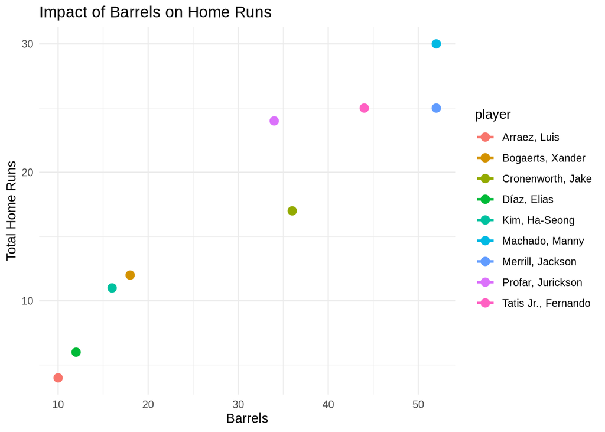

```r
sd_player_stats |>
  ggplot(aes(x = barrels, y = hr_total, color = player)) +
    geom_point(size = 3) +
    geom_smooth(method = "lm", se = FALSE) +
    labs(
      title = "Impact of Barrels on Home Runs",
      x = "Barrels",
      y = "Total Home Runs"
    ) +
    theme_minimal()
```

Players with higher barrels, such as Manny Machado exhibit a proportional increase in total home runs. This analysis reinforces the importance of barrels as a metric for offensive success.

#### Performance by Home Run Efficiency

Analyzing Home Run Efficiency across players highlights those exceeding expectations in home run performance. Positive efficiency values for players like Fernando Tatis Jr. and Manny Machado underscore their ability to outperform expected home run metrics. Conversely, players with negative efficiency values indicate potential areas for improvement in quality contact.

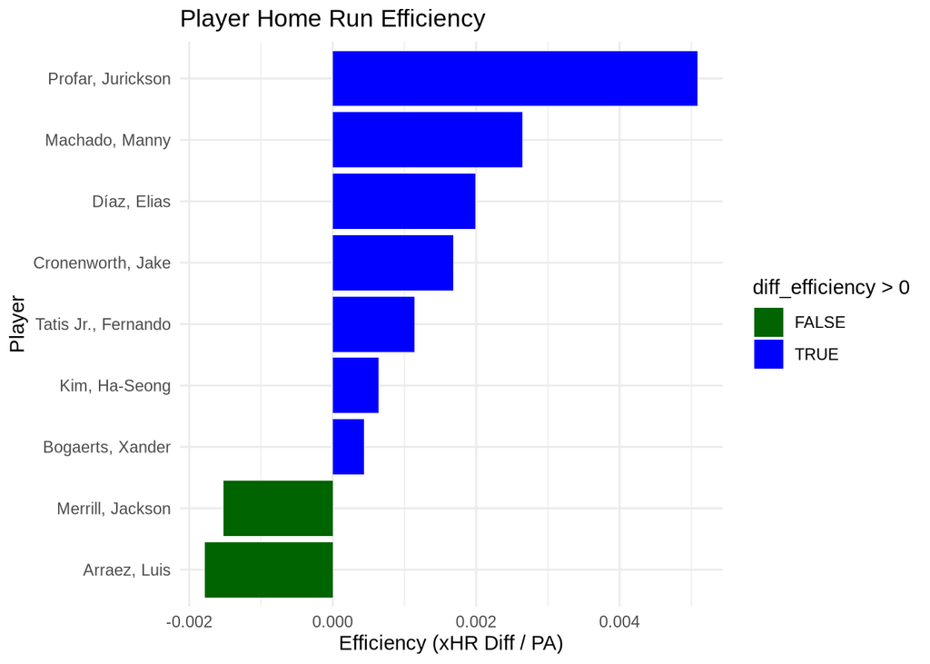

```r
sd_player_stats |>
  ggplot(aes(x = reorder(player, diff_efficiency), y = diff_efficiency, fill = diff_efficiency > 0)) +
    geom_bar(stat = "identity") +
    coord_flip() +
    labs(
      title = "Player Home Run Efficiency",
      x = "Player",
      y = "Efficiency (xHR Diff / PA)"
    ) +
    scale_fill_manual(values = c("TRUE" = "blue", "FALSE" = "darkgreen")) +
    theme_minimal()
```

#### Histogram for average home run trot time

These histograms provide an essential understanding of player performance patterns. The distribution of average home run trot times helps us explore typical behaviors after a home run, which could be linked to player styles or game situations. Analyzing the expected home run differences (XHR Diff) sheds light on how well players meet or exceed expectations, highlighting outliers who might be overperforming or underperforming. These insights help contextualize player performance and identify trends or anomalies that could influence further analysis.

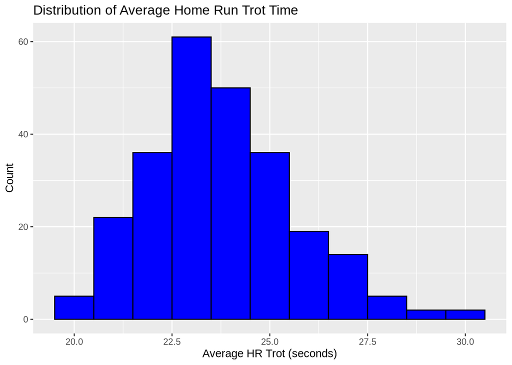

```r
ggplot(all_player_stats, aes(x = avg_hr_trot)) +
  geom_histogram(binwidth = 1, fill = "blue", color = "black") +
  labs(title = "Distribution of Average Home Run Trot Time",
       x = "Average HR Trot (seconds)", y = "Count")
```

The first histogram displays the distribution of average home run trot times, showcasing a roughly normal distribution centered around 23–24 seconds. This provides insight into the time players typically take to round the bases after hitting a home run.

#### Histogram for expected HR differences

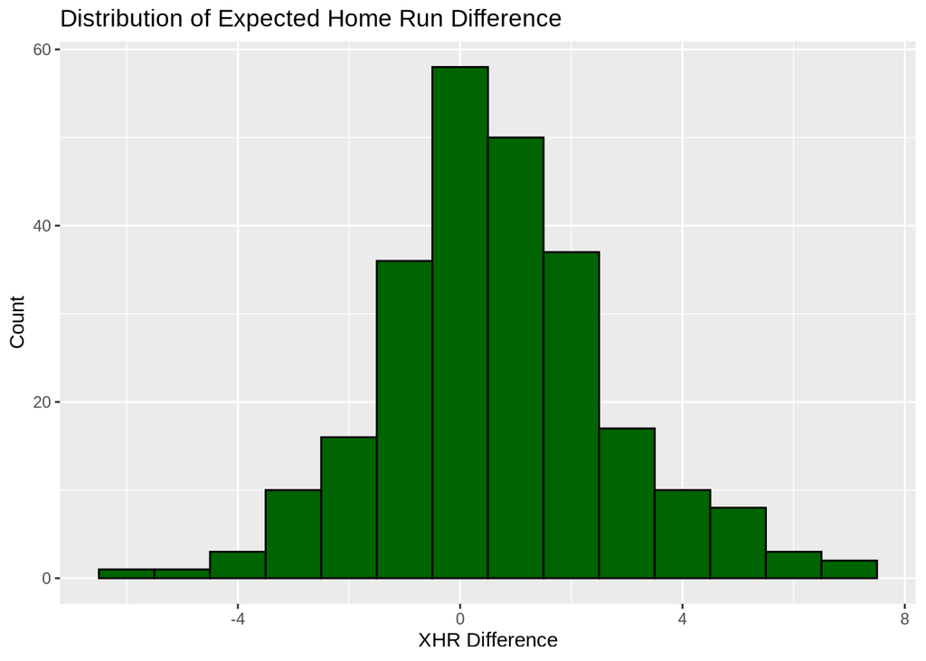

```r
ggplot(all_player_stats, aes(x = xhr_diff)) +
  geom_histogram(binwidth = 1, fill = "darkgreen", color = "black") +
  labs(title = "Distribution of Expected Home Run Difference",
       x = "XHR Difference", y = "Count")
```

The second histogram illustrates the distribution of the expected home run (XHR) differences, indicating that most players hover around zero, meaning their actual home runs are close to expectations. Outliers in the positive or negative direction suggest players exceeding or underperforming relative to their expected home runs.

#### Relationship Between Variables

We analyzing relationships between variables to helps identify key factors influencing home run performance such as power consistency (No Doubter Percentage) and efficiency (XHR Difference). This understanding supports feature selection for predictive models and provides insights into player performance dynamic

##### Scatter plot for xhr_diff vs. avg_hit_speed

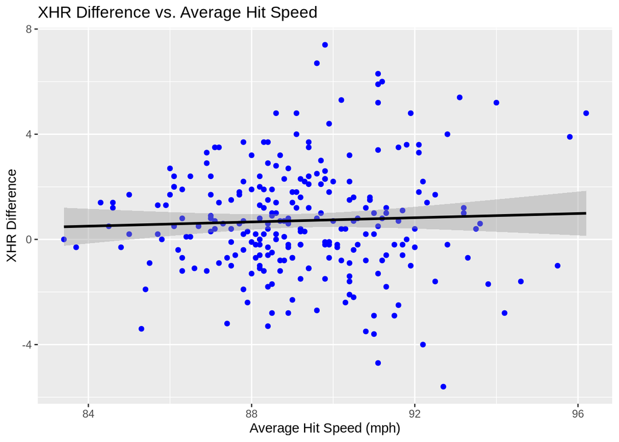

```r
ggplot(all_player_stats, aes(x = avg_hit_speed, y = xhr_diff)) +
  geom_point(color = "blue") +
  geom_smooth(method = "lm", se = TRUE, color = "black") +
  labs(title = "XHR Difference vs. Average Hit Speed",
       x = "Average Hit Speed (mph)", y = "XHR Difference")
```

The first scatter plot illustrates the relationship between **XHR Difference** and **Average Hit Speed (mph)**. It demonstrates a weak positive correlation suggesting that higher average hit speeds slightly contribute to players exceeding their expected home run (XHR) values.

##### Scatter plot for no_doubter_per vs. hr_total with trend line

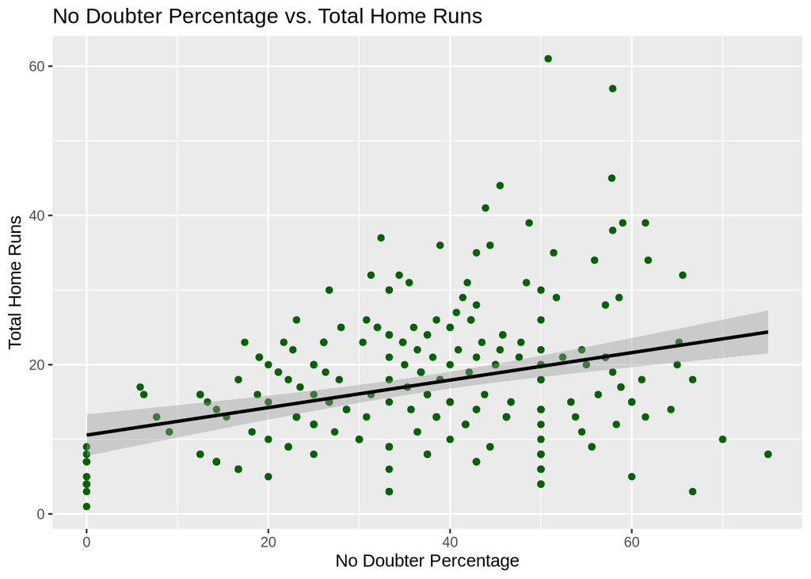

```r
ggplot(all_player_stats, aes(x = no_doubter_per, y = hr_total)) +
  geom_point(color = "darkgreen") +
  geom_smooth(method = "lm", se = TRUE, color = "black") +
  labs(title = "No Doubter Percentage vs. Total Home Runs",
       x = "No Doubter Percentage", y = "Total Home Runs")
```

The second scatter plot explores the relationship between **No Doubter Percentage** and **Total Home Runs**. This plot indicates a positive trend showing that as the percentage of “No Doubter” home runs increases, the total number of home runs tends to rise, revealing a potential measure of power and consistency among players.

#### Comparing Padres to MLB Average

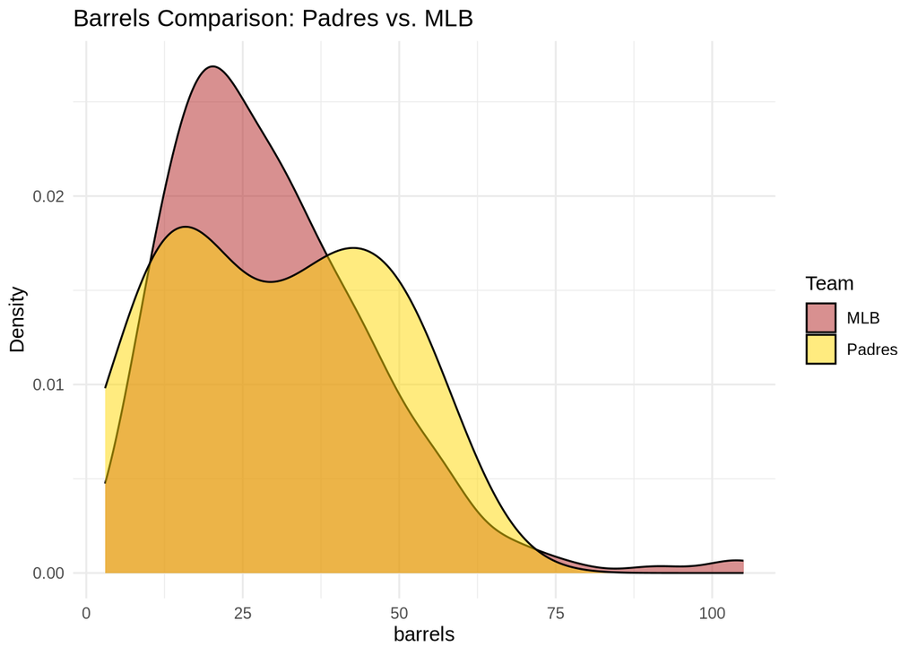

```r
padres_stats <- sd_player_stats |>
  select(player, barrels, avg_hit_speed, est_woba) |>
  rename(avg_exit_velocity = avg_hit_speed)
mlb_stats <- all_player_stats |>
  select(player, barrels, avg_hit_speed, est_woba) |>
  rename(avg_exit_velocity = avg_hit_speed)
metrics <- c("barrels", "avg_exit_velocity", "est_woba")
create_density_plot <- function(metric, title) {
  ggplot() +
    geom_density(data = mlb_stats, aes_string(x = metric, fill = "\"MLB\""), alpha = 0.5) +
    geom_density(data = padres_stats, aes_string(x = metric, fill = "\"Padres\""), alpha = 0.5) +
    scale_fill_manual(values = c("MLB" = "#B22222", "Padres" = "gold")) +
    labs(
      title = title,
      x = metric,
      y = "Density",
      fill = "Team"
    ) +
    theme_minimal()
}
density_plots <- list(
  create_density_plot("barrels", "Barrels Comparison: Padres vs. MLB"),
  create_density_plot("avg_exit_velocity", "Average Exit Velocity Comparison: Padres vs. MLB"),
  create_density_plot("est_woba", "xwOBA Comparison: Padres vs. MLB")
)
print(density_plots[[1]])
```

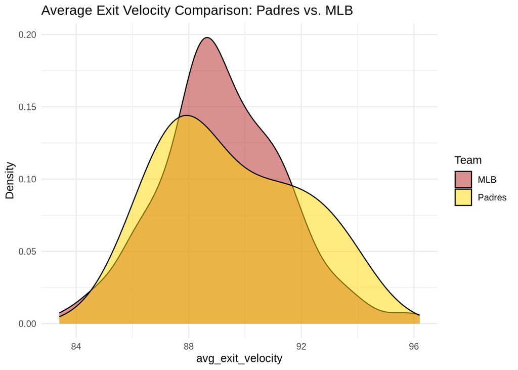

```r
print(density_plots[[2]])
```

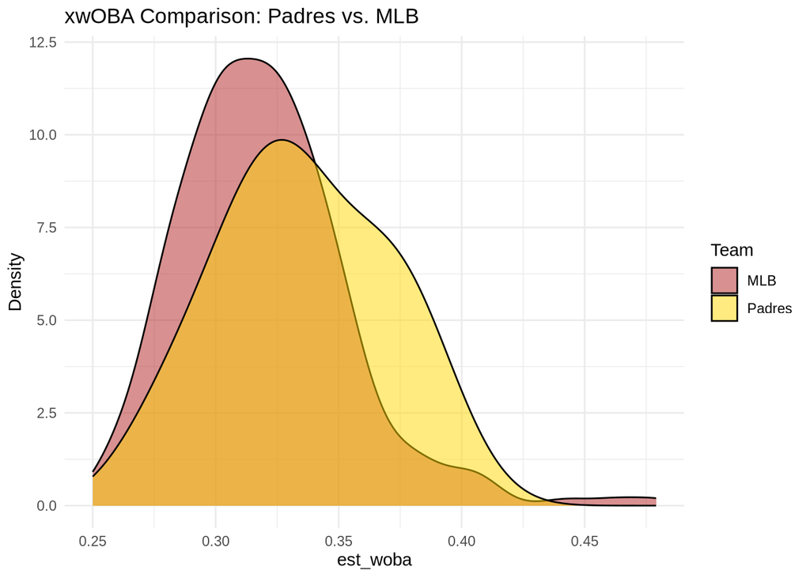

```r
print(density_plots[[3]])
```

#### Percentile Rankings

We will calculate percentile rankings for key metrics to contextualize individual player performance within the league. For example, if a player’s barrel rate is in the 90th percentile, they are among the league’s top performers in generating high-quality contact.

```r
padres_percentiles <- padres_stats |>
  select(player, barrels, avg_exit_velocity, est_woba) |>
  mutate(
    barrels_percentile = percent_rank(barrels),
    avg_exit_velocity_percentile = percent_rank(avg_exit_velocity),
    xwOBA_percentile = percent_rank(est_woba)
  )
head(padres_percentiles |>  arrange(desc(barrels_percentile)))
```

```
##                player barrels avg_exit_velocity est_woba barrels_percentile
## 1      Machado, Manny      52              92.5    0.338              0.875
## 2    Merrill, Jackson      52              90.4    0.372              0.875
## 3 Tatis Jr., Fernando      44              93.5    0.387              0.750
## 4   Cronenworth, Jake      36              88.6    0.335              0.625
## 5   Profar, Jurickson      34              91.1    0.364              0.500
## 6    Bogaerts, Xander      18              88.1    0.305              0.375
##   avg_exit_velocity_percentile xwOBA_percentile
## 1                        0.875            0.625
## 2                        0.625            0.875
## 3                        1.000            1.000
## 4                        0.500            0.500
## 5                        0.750            0.750
## 6                        0.375            0.125
```

The EDA reveals several critical insights into factors driving player performance and game outcomes for the San Diego Padres. Exit velocity and barrels emerge as key predictors of offensive success, while xwOBA effectively summarizes a player’s overall contribution. Key players like Manny Machado and Fernando Tatis Jr. consistently outperform expectations, particularly in home run efficiency. These findings provide a foundation for more advanced modeling and strategy optimization to enhance team performance.

## Data Analysis

This section presents a comprehensive data analysis of the factors influencing home run performance using Statcast metrics. We employed a combination of analytical techniques including correlation analysis, linear regression, and random forest modeling to explore relationships and predict key performance metrics. The **correlation matrix** helped identify significant relationships between variables and detect multicollinearity, where two or more features are highly correlated, potentially distorting their individual contributions. To address this, we applied appropriate modeling techniques. We selected two complementary models for predicting home run performance: **Linear Regression** and **Random Forest**. We chose Linear Regression for its interpretability and ability to quantify relationships using coefficients and p-values, highlighting statistically significant metrics. Additionally, we applied Random Forest to capture complex, non-linear interactions and reduce overfitting through its ensemble learning approach. Model performance was evaluated using R², RMSE, and MAE, ensuring accurate and reliable predictions of home run totals.

### Correlation Matrix

```r
numeric_vars <- all_player_stats |>
  select(xhr_diff, hr_total, avg_hit_speed, no_doubter_per)

cor_matrix <- cor(numeric_vars, use = "complete.obs")
print(cor_matrix)
```

```
##                   xhr_diff  hr_total avg_hit_speed no_doubter_per
## xhr_diff        1.00000000 0.2550773    0.04273631     -0.2891469
## hr_total        0.25507733 1.0000000    0.64701164      0.3138962
## avg_hit_speed   0.04273631 0.6470116    1.00000000      0.3821946
## no_doubter_per -0.28914689 0.3138962    0.38219464      1.0000000
```

The correlation matrix highlights higher average hit speed (avg_hit_speed) is strongly associated with more home runs (hr_total) which is expected given that stronger hits are more likely to result in home runs. The negative correlation between xhr_diff and no_doubter_per suggests that players with higher percentages of no-doubt home runs tend to have smaller differences between actual and expected home run counts.

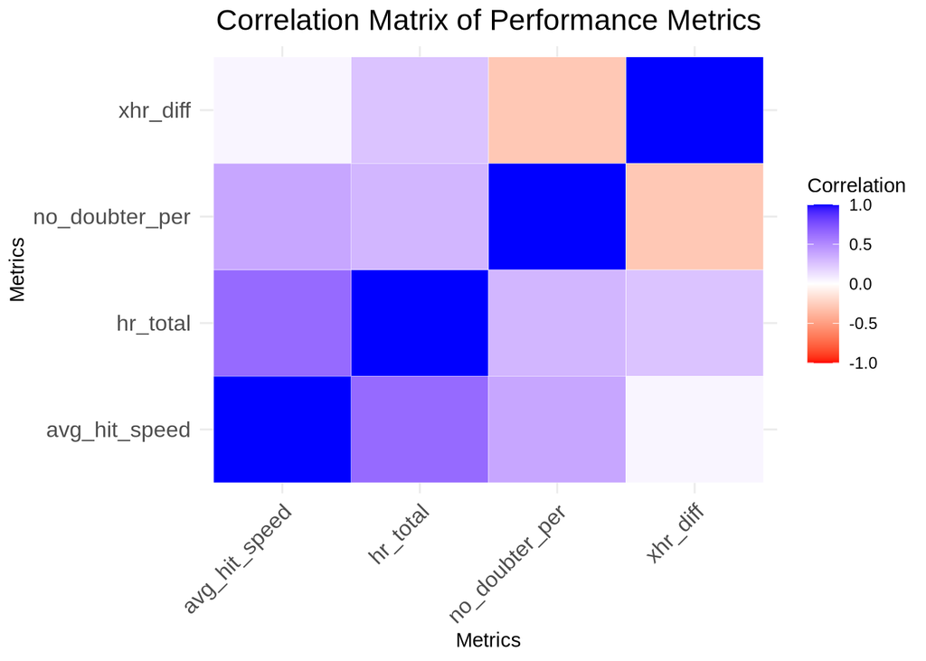

```r
cor_matrix_tidy <- cor_matrix |>
  as.data.frame() |>
  rownames_to_column(var = "Var1") |>
  pivot_longer(cols = -Var1, names_to = "Var2", values_to = "Freq")

ggplot(cor_matrix_tidy, aes(Var1, Var2, fill = Freq)) +
  geom_tile(color = "white") +
  scale_fill_gradient2(low = "red", high = "blue", mid = "white", midpoint = 0,
                       limit = c(-1, 1), name = "Correlation") +
  theme_minimal() +
  labs(title = "Correlation Matrix of Performance Metrics",
       x = "Metrics", y = "Metrics") +
  theme(
    axis.text.x = element_text(angle = 45, vjust = 1, hjust = 1, size = 12),
    axis.text.y = element_text(size = 12),
    plot.title = element_text(hjust = 0.5, size = 16)
  )
```

### Data Splitting and Preprocessing

The model evaluation and visualization section provides an assessment of the performance of the predictive models, including key metrics like R² and error analysis, alongside visual aids such as scatterplots and feature importance graphs to illustrate the relationship between input variables and predicted outcomes. These evaluations help ensure that the models are robust and accurately reflect the underlying patterns in the data.

#### Data Splitting

We decided to split the dataset into 80% training and 20% testing sets to evaluate the model’s performance on unseen data and verify a reliable assessment of its predictive accuracy.

```r
set.seed(123)
data_split <- initial_split(all_player_stats, prop = 0.8)  # 80% training, 20% testing
train_data <- training(data_split)
test_data <- testing(data_split)
nrow(train_data)  # Number of training samples
```

```
## [1] 201
```

```r
nrow(test_data)   # Number of testing samples
```

```
## [1] 51
```

#### Data Preprocessing

Before model training, we applied standard preprocessing steps, including centering and scaling numeric features to standardize variable ranges. We also performed correlation filtering to address multicollinearity, ensuring that each feature contributes unique information to the model. This improved model interpretability and reduced potential overfitting.

```r
rec <- recipe(hr_total ~ avg_hit_speed + barrels + no_doubter_per + xhr_diff, data = train_data) |>
  step_center(all_predictors()) |>
  step_scale(all_predictors()) |>
  step_corr(all_predictors(), threshold = 0.9)

prepped_data <- prep(rec, training = train_data)
train_preprocessed <- bake(prepped_data, new_data = NULL)
test_preprocessed <- bake(prepped_data, new_data = test_data)
```

#### Model Performance Evaluation

```r
lm_model <- lm(hr_total ~ avg_hit_speed + barrels + no_doubter_per + xhr_diff, data = train_preprocessed)
summary(lm_model)
```

```
##
## Call:
## lm(formula = hr_total ~ avg_hit_speed + barrels + no_doubter_per +
##     xhr_diff, data = train_preprocessed)
##
## Residuals:
##     Min      1Q  Median      3Q     Max
## -7.2750 -2.2799 -0.3814  2.3791 14.0712
##
## Coefficients:
##                Estimate Std. Error t value Pr(>|t|)
## (Intercept)     17.1642     0.2366  72.548  < 2e-16 ***
## avg_hit_speed   -1.2139     0.3789  -3.204  0.00158 **
## barrels          8.7622     0.3764  23.276  < 2e-16 ***
## no_doubter_per   0.7424     0.2722   2.727  0.00697 **
## xhr_diff         1.7873     0.2540   7.038  3.2e-11 ***
## ---
## Signif. codes:  0 '***' 0.001 '**' 0.01 '*' 0.05 '.' 0.1 ' ' 1
##
## Residual standard error: 3.354 on 196 degrees of freedom
## Multiple R-squared:  0.8679, Adjusted R-squared:  0.8652
## F-statistic: 321.8 on 4 and 196 DF,  p-value: < 2.2e-16
```

```r
test_predictions <- test_preprocessed |>
  mutate(predicted_hr_total = predict(lm_model, newdata = test_preprocessed))
test_predictions |>
  metrics(truth = hr_total, estimate = predicted_hr_total)
```

```
## # A tibble: 3 × 3
##   .metric .estimator .estimate
##   <chr>   <chr>          <dbl>
## 1 rmse    standard       2.77
## 2 rsq     standard       0.928
## 3 mae     standard       2.33
```

### Linear Regression

To further our analysis, We built two linear regression models: one for San Diego Padres players (sd_lm_model) and another for all players in the dataset (all_lm_model). These models explored the relationship between total home runs (hr_total) and key performance metrics, including average hit speed, barrels, no-doubter percentage, and expected home run differences (XHR Diff). By applying linear regression, we assessed how these variables collectively influence a player’s home run performance, providing insights into the factors that contribute most significantly to home run production.

#### Model for the San Diego Padres Data

```r
sd_lm_model <- lm(hr_total ~ avg_hit_speed + barrels + no_doubter_per + xhr_diff, data = sd_player_stats)
summary(sd_lm_model)
```

```
##
## Call:
## lm(formula = hr_total ~ avg_hit_speed + barrels + no_doubter_per +
##     xhr_diff, data = sd_player_stats)
##
## Residuals:
##       1       2       3       4       5       6       7       8       9
##  0.3721  0.6049 -1.1961  0.6497 -1.3150  1.9017  1.1236 -1.8627 -0.2782
##
## Coefficients:
##                 Estimate Std. Error t value Pr(>|t|)
## (Intercept)    -91.27923   47.86828  -1.907  0.12921
## avg_hit_speed    1.08006    0.55786   1.936  0.12494
## barrels          0.37540    0.08073   4.650  0.00966 **
## no_doubter_per  -0.01535    0.04025  -0.381  0.72237
## xhr_diff         1.17156    0.56382   2.078  0.10628
## ---
## Signif. codes:  0 '***' 0.001 '**' 0.01 '*' 0.05 '.' 0.1 ' ' 1
##
## Residual standard error: 1.769 on 4 degrees of freedom
## Multiple R-squared:  0.982,  Adjusted R-squared:  0.9641
## F-statistic:  54.7 on 4 and 4 DF,  p-value: 0.0009555
```

The model shows that `barrels` is the most statisically significant factor influencing total home runs in the San Diego Padres with a strong positive relationship. Showing that for every additional barrel, the expected number of homeruns increases by 0.375. While the `no_doubter_per` does not appear to significantly affect home runs. Overall, the model explains 96.41% of the variability in home runs.

#### Model for MLB-Wide Data

Since the Padres only have 9 players, and we want to see if those performance metrics are accurately determining player’s success, we do the same model on all the players in the MLB. To validate whether these metrics apply to a broader context, we extended the model to include all MLB players.

```r
all_lm_model <- lm(hr_total ~ avg_hit_speed + barrels + no_doubter_per + xhr_diff, data = all_player_stats)
summary(all_lm_model)
```

```
##
## Call:
## lm(formula = hr_total ~ avg_hit_speed + barrels + no_doubter_per +
##     xhr_diff, data = all_player_stats)
##
## Residuals:
##     Min      1Q  Median      3Q     Max
## -7.0167 -2.3099 -0.3197  2.2318 14.1854
##
## Coefficients:
##                Estimate Std. Error t value Pr(>|t|)
## (Intercept)    51.00890   12.42521   4.105 5.49e-05 ***
## avg_hit_speed  -0.58991    0.14496  -4.070 6.34e-05 ***
## barrels         0.55438    0.01936  28.628  < 2e-16 ***
## no_doubter_per  0.04485    0.01479   3.032  0.00269 **
## xhr_diff        1.00300    0.10447   9.601  < 2e-16 ***
## ---
## Signif. codes:  0 '***' 0.001 '**' 0.01 '*' 0.05 '.' 0.1 ' ' 1
##
## Residual standard error: 3.233 on 247 degrees of freedom
## Multiple R-squared:  0.883,  Adjusted R-squared:  0.8811
## F-statistic: 466.1 on 4 and 247 DF,  p-value: < 2.2e-16
```

When the model is applied to all MLB players, we observe similar relationships where `barrels` remains the most significant factor with every barrel contributing to 0.554 homeruns. Overall, the model explains 88.1% of the variability in homeruns which is still quite strong.

#### Random Forest

We trained a Random Forest model to predict home run totals and assess feature importance using “Mean Decrease in Gini.” This metric measures how much a feature contributes to the accuracy of the Random Forest model by indicating its impact on splitting the data and reducing impurity in decision trees. Features with higher Mean Decrease in Gini values have a stronger influence on the model’s predictions making them more critical for accurate outcomes.

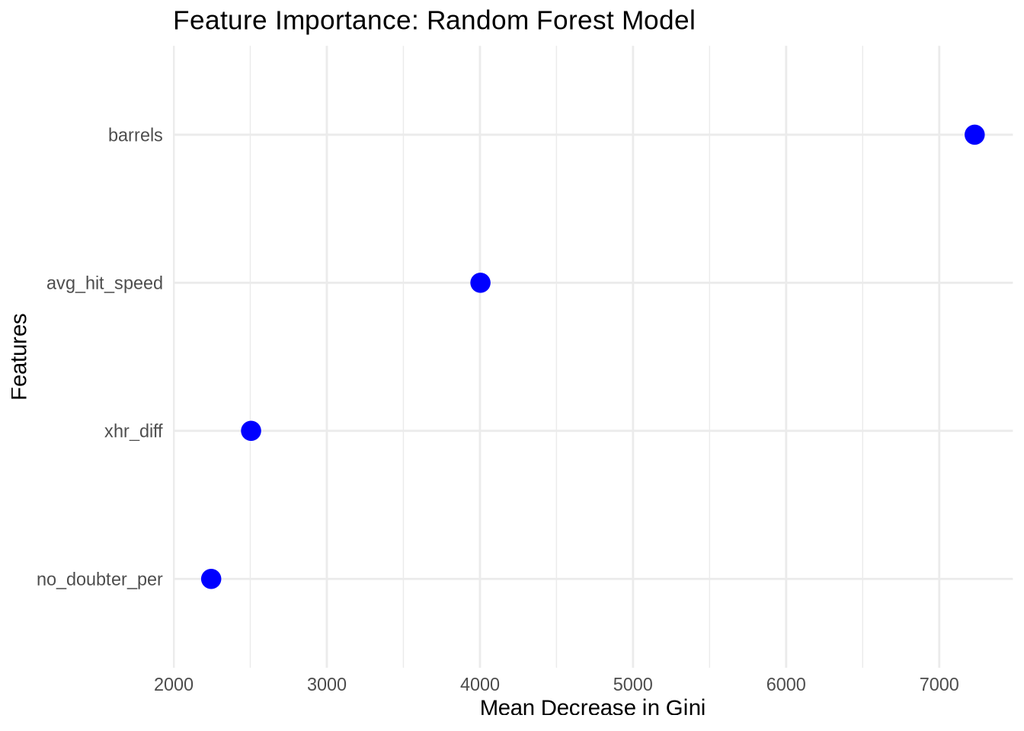

```r
set.seed(123)
rf_model <- randomForest(
  hr_total ~ avg_hit_speed + barrels + no_doubter_per + xhr_diff,
  data = train_preprocessed,
  ntree = 500
)
importance_df <- as.data.frame(importance(rf_model))
importance_df$Feature <- rownames(importance_df)
colnames(importance_df) <- c("MeanDecreaseGini", "Feature")
importance_plot <- importance_df |>
  arrange(desc(MeanDecreaseGini)) |>
  ggplot(aes(x = reorder(Feature, MeanDecreaseGini), y = MeanDecreaseGini)) +
  geom_point(color = "blue", size = 4) +
  coord_flip() +
  labs(
    title = "Feature Importance: Random Forest Model",
    x = "Features",
    y = "Mean Decrease in Gini"
  ) +
  theme_minimal()
importance_plot
```

The Random Forest model identified barrels as the most critical predictor of home run totals, followed by average hit speed, XHR Diff, and no-doubter percentage, as shown in the feature importance graph. The Mean Decrease in Gini highlights the relative contribution of each feature emphasizing that barrels play a significant role in improving the model’s predictive accuracy. Compared to the linear regression model, which explained 93% of the variance in home runs, Random Forest provided greater flexibility in capturing complex relationships as demonstrated in subsequent scatterplots. This underscores the importance of consistent high-quality contact in driving home run performance.